# Get started

This page aims to give an overview of `DGrowthR` and introduce you to the main functions that you might want to use for your own analysis. Broadly speaking, this tutorial is divided into the following sections:

1. Preparing your data for `DGrowthR`. [Required]
2. Preparing a DGrowthR object. [Required]
3. Pre-processing. [Required]
4. Exploratory data analysis.
5. Growth parameter calculation.
6. Differential growth testing.
7. Multiple differential growth testing.

```r
library("tidyverse")

library("DGrowthR")
```

## Preparing your data for `DGrowthR`.

To start our analysis we first need to prepare a `DGrowthR::DGrowthR()` object. To do this, we require two sources of information:  
1. Growth data. 2. Metadata.

Below we will go into more details of each one.

### Growth data.

`DGrowthR` can be used to analyse growth data from multi-well plate readers. Depending on the specific platform that is used, the actual output of each machine might look slightly different. **`DGrowthR` assumes your data consists of simultaneous measurements of growth**, preferably that are regularly interspaced. This means that the growth across all wells is measured at the same time and, ideally, that the time between measurements is always the same. If the data is not measured at regular intervals, `DGrowthR` will still be able to analyze your data. Examples of the kinds of data the can be used can be seen in our [Source Data](https://github.com/bio-datascience/DGrowthR/tree/main/Source_Data) folder.

** Below is an example of the data collected for one 384 well plate from [Brenzinger 2024](https://www.nature.com/articles/s41564-023-01556-y). This dataframe could be used directly to build a `DGrowthR::DGrowthR()` object. The important features include: **

1. A column called **Time**: The values in this column indicate the time at which the OD measurements were made for all of the wells in this plate. The units of the **Time** column (seconds, minutes, hours) are taken *as is*. No unit conversion is performed by `DGrowthR`.
2. Columns indicating wells: All of the columns besides the **Time** column indicate the wells in the plate. The values are the measured optical density in each well at a specific time point.
3. An arbitrary number of wells can be present (typically 384 or 96). Typically, each well is identified as a combination of an uppercase letter followed by a number, with no spaces. This information is used to identify each individual growth curve.

[Source_Data/Brenzinger_2024/wt_1_OD.txt](https://github.com/bio-datascience/DGrowthR/blob/main/Source_Data/Brenzinger_2024/od_data/wt_1_OD.txt)

```r
# Read example data from Brenzinger 2024
example_brenzinger <- read.delim("../source_data/od_data/wt_1_OD.txt",
                                 sep = '\t')

tibble(example_brenzinger) %>%
  rmarkdown::paged_table()
```

| Time | A1 | A2 | A3 | A4 | A5 | A6 | A7 | A8 | A9 | A10 | A11 | A12 | A13 | A14 | A15 | A16 | A17 | A18 | A19 | A20 | A21 | A22 | A23 | A24 | B1 | B2 | B3 | B4 | B5 | … |
| --- | --- | --- | --- | --- | --- | --- | --- | --- | --- | --- | --- | --- | --- | --- | --- | --- | --- | --- | --- | --- | --- | --- | --- | --- | --- | --- | --- | --- | --- | --- |
| 0.000000 | 0.102 | 0.105 | 0.107 | 0.103 | 0.102 | 0.101 | 0.122 | 0.106 | 0.106 | 0.106 | 0.101 | 0.101 | 0.109 | 0.102 | 0.098 | 0.098 | 0.098 | 0.103 | 0.100 | 0.097 | 0.100 | 0.107 | 0.104 | 0.105 | 0.100 | 0.101 | 0.102 | 0.100 | 0.103 | … |
| 1.923611 | 0.166 | 0.167 | 0.160 | 0.156 | 0.146 | 0.152 | 0.151 | 0.144 | 0.136 | 0.154 | 0.166 | 0.166 | 0.156 | 0.152 | 0.131 | 0.134 | 0.162 | 0.170 | 0.164 | 0.162 | 0.134 | 0.142 | 0.138 | 0.139 | 0.166 | 0.163 | 0.160 | 0.151 | 0.157 | … |
| 2.662778 | 0.237 | 0.236 | 0.212 | 0.217 | 0.179 | 0.201 | 0.162 | 0.170 | 0.133 | 0.194 | 0.220 | 0.243 | 0.213 | 0.217 | 0.133 | 0.138 | 0.249 | 0.255 | 0.234 | 0.225 | 0.135 | 0.146 | 0.137 | 0.136 | 0.238 | 0.233 | 0.227 | 0.211 | 0.205 | … |
| 3.402222 | 0.303 | 0.293 | 0.294 | 0.289 | 0.229 | 0.279 | 0.209 | 0.251 | 0.131 | 0.223 | 0.285 | 0.341 | 0.278 | 0.281 | 0.131 | 0.138 | 0.363 | 0.358 | 0.317 | 0.303 | 0.134 | 0.168 | 0.137 | 0.135 | 0.314 | 0.308 | 0.318 | 0.307 | 0.300 | … |
| 4.141389 | 0.448 | 0.436 | 0.343 | 0.409 | 0.293 | 0.372 | 0.293 | 0.324 | 0.129 | 0.248 | 0.364 | 0.389 | 0.365 | 0.377 | 0.130 | 0.139 | 0.377 | 0.448 | 0.373 | 0.378 | 0.133 | 0.226 | 0.136 | 0.134 | 0.431 | 0.424 | 0.419 | 0.393 | 0.370 | … |
| 4.880833 | 0.539 | 0.540 | 0.436 | 0.474 | 0.375 | 0.449 | 0.364 | 0.427 | 0.128 | 0.268 | 0.378 | 0.435 | 0.482 | 0.501 | 0.130 | 0.141 | 0.388 | 0.511 | 0.466 | 0.438 | 0.131 | 0.273 | 0.133 | 0.133 | 0.530 | 0.528 | 0.484 | 0.480 | 0.459 | … |
| 5.620000 | 0.607 | 0.595 | 0.488 | 0.523 | 0.423 | 0.514 | 0.477 | 0.536 | 0.131 | 0.277 | 0.362 | 0.466 | 0.573 | 0.542 | 0.132 | 0.146 | 0.409 | 0.550 | 0.547 | 0.535 | 0.133 | 0.361 | 0.135 | 0.134 | 0.605 | 0.610 | 0.545 | 0.547 | 0.542 | … |
| 6.359167 | 0.681 | 0.659 | 0.541 | 0.574 | 0.462 | 0.585 | 0.573 | 0.586 | 0.129 | 0.285 | 0.326 | 0.501 | 0.651 | 0.652 | 0.130 | 0.147 | 0.394 | 0.647 | 0.599 | 0.633 | 0.132 | 0.507 | 0.135 | 0.134 | 0.682 | 0.687 | 0.592 | 0.592 | 0.614 | … |
| 7.098333 | 0.756 | 0.715 | 0.570 | 0.618 | 0.517 | 0.642 | 0.638 | 0.682 | 0.128 | 0.281 | 0.209 | 0.550 | 0.744 | 0.748 | 0.129 | 0.150 | 0.353 | 0.724 | 0.639 | 0.706 | 0.131 | 0.581 | 0.135 | 0.133 | 0.770 | 0.778 | 0.638 | 0.632 | 0.662 | … |
| 7.837500 | 0.808 | 0.771 | 0.610 | 0.653 | 0.572 | 0.702 | 0.691 | 0.760 | 0.127 | 0.256 | 0.185 | 0.632 | 0.817 | 0.822 | 0.130 | 0.153 | 0.337 | 0.796 | 0.740 | 0.761 | 0.133 | 0.658 | 0.136 | 0.136 | 0.815 | 0.821 | 0.692 | 0.705 | 0.714 | … |

[output cut: 10 more lines]

As stated above, this data frame could be used directly by `DGrowthR`.

#### What if I want to analyze data from multiple plates?.

This is definitely possible with `DGrowthR`. There are just a couple of things to keep in mind:

1. The data for each plate should be in separate files.
2. It is assumed that measurements are taken at roughly the same timepoints across all plates. This means that the **Time** column should be roughly the same for all plates. Due to small variations between different plate measurements, the values in the **Time** column might be slightly different.
3. Each growth curve will now be identified as the combination of {plate name}_{well}.

In order to read the data from multiple plates, harmonize the **Time** column, and assign individual curve identifiers in a way that can be used by `DGrowthR`, we provide a standalone function called `read_multiple_plates()`. Below, we use it to read all of the data from the [Brenzinger 2024](https://www.nature.com/articles/s41564-023-01556-y) study. In this case we know that 20 measurements are taken; the time between the first and second measurement is ~2 hours, followed by regular 44 minute intervals. This can help us create a common time vector for all files.

```r
# Create common time vector
common_time_vector <- c(0, 2, seq(from=2.739, by=0.739, length.out=18))

# Read all OD data
brenzinger_data <- read_multiple_plates(path_target = "../source_data/od_data/",
                                        time_vector = common_time_vector)
```

```
#> The following OD data was found: dCBASS_1_OD.txt, dCBASS_2_OD.txt, dCBASS_3_OD.txt, wt_1_OD.txt, wt_2_OD.txt, wt_3_OD.txt
```

The output of this function is a list with two data frames. First is the “od_data” data frame. As you can see, it has a common **Time** column with each individual growth curve in remaining columns. Each growth is now identified with a **curve_id** which is built as {plate_name}_{well}, with the plate_name actually just being the name of the file from which the data was read, without the extension. In total there are 20 measurements for 2,304 (384 * 6) growth curves!

```r
# Show the first five columns of the complete OD data
brenzinger_od <- brenzinger_data[["od_data"]]


brenzinger_od %>%
  rmarkdown::paged_table()
```

| Time | dCBASS_1_OD_A1 | dCBASS_1_OD_A2 | dCBASS_1_OD_A3 | dCBASS_1_OD_A4 | dCBASS_1_OD_A5 | dCBASS_1_OD_A6 | dCBASS_1_OD_A7 | dCBASS_1_OD_A8 | dCBASS_1_OD_A9 | dCBASS_1_OD_A10 | dCBASS_1_OD_A11 | dCBASS_1_OD_A12 | dCBASS_1_OD_A13 | dCBASS_1_OD_A14 | dCBASS_1_OD_A15 | dCBASS_1_OD_A16 | dCBASS_1_OD_A17 | dCBASS_1_OD_A18 | dCBASS_1_OD_A19 | dCBASS_1_OD_A20 | dCBASS_1_OD_A21 | dCBASS_1_OD_A22 | dCBASS_1_OD_A23 | dCBASS_1_OD_A24 | dCBASS_1_OD_B1 | dCBASS_1_OD_B2 | dCBASS_1_OD_B3 | dCBASS_1_OD_B4 | dCBASS_1_OD_B5 | … |
| --- | --- | --- | --- | --- | --- | --- | --- | --- | --- | --- | --- | --- | --- | --- | --- | --- | --- | --- | --- | --- | --- | --- | --- | --- | --- | --- | --- | --- | --- | --- |
| 0.000 | 0.164 | 0.123 | 0.117 | 0.120 | 0.118 | 0.115 | 0.122 | 0.120 | 0.111 | 0.112 | 0.115 | 0.125 | 0.128 | 0.121 | 0.117 | 0.139 | 0.124 | 0.119 | 0.106 | 0.113 | 0.114 | 0.125 | 0.139 | 0.149 | 0.125 | 0.122 | 0.115 | 0.117 | 0.118 | … |
| 2.000 | 0.292 | 0.237 | 0.215 | 0.225 | 0.189 | 0.210 | 0.202 | 0.195 | 0.166 | 0.214 | 0.232 | 0.242 | 0.212 | 0.221 | 0.154 | 0.179 | 0.233 | 0.235 | 0.220 | 0.203 | 0.151 | 0.152 | 0.155 | 0.172 | 0.246 | 0.237 | 0.223 | 0.224 | 0.214 | … |
| 2.739 | 0.343 | 0.284 | 0.281 | 0.284 | 0.238 | 0.286 | 0.263 | 0.266 | 0.161 | 0.256 | 0.323 | 0.345 | 0.282 | 0.283 | 0.152 | 0.181 | 0.340 | 0.330 | 0.280 | 0.251 | 0.146 | 0.182 | 0.155 | 0.169 | 0.295 | 0.294 | 0.285 | 0.281 | 0.296 | … |
| 3.478 | 0.480 | 0.417 | 0.328 | 0.377 | 0.299 | 0.340 | 0.325 | 0.331 | 0.159 | 0.275 | 0.398 | 0.439 | 0.346 | 0.388 | 0.152 | 0.180 | 0.427 | 0.429 | 0.367 | 0.342 | 0.146 | 0.242 | 0.152 | 0.165 | 0.432 | 0.402 | 0.376 | 0.374 | 0.341 | … |
| 4.217 | 0.610 | 0.551 | 0.439 | 0.504 | 0.374 | 0.442 | 0.410 | 0.455 | 0.157 | 0.276 | 0.500 | 0.517 | 0.503 | 0.523 | 0.153 | 0.187 | 0.440 | 0.509 | 0.474 | 0.454 | 0.147 | 0.288 | 0.153 | 0.166 | 0.559 | 0.545 | 0.492 | 0.505 | 0.469 | … |
| 4.956 | 0.678 | 0.607 | 0.505 | 0.562 | 0.414 | 0.522 | 0.529 | 0.550 | 0.156 | 0.287 | 0.549 | 0.597 | 0.602 | 0.615 | 0.154 | 0.197 | 0.451 | 0.561 | 0.581 | 0.539 | 0.147 | 0.415 | 0.157 | 0.165 | 0.630 | 0.606 | 0.558 | 0.571 | 0.544 | … |
| 5.695 | 0.757 | 0.682 | 0.542 | 0.607 | 0.459 | 0.597 | 0.576 | 0.622 | 0.156 | 0.295 | 0.556 | 0.666 | 0.699 | 0.716 | 0.154 | 0.195 | 0.465 | 0.634 | 0.642 | 0.597 | 0.146 | 0.511 | 0.154 | 0.165 | 0.730 | 0.693 | 0.616 | 0.627 | 0.613 | … |
| 6.434 | 0.819 | 0.742 | 0.585 | 0.637 | 0.529 | 0.667 | 0.635 | 0.690 | 0.153 | 0.309 | 0.533 | 0.724 | 0.794 | 0.785 | 0.154 | 0.194 | 0.483 | 0.723 | 0.713 | 0.642 | 0.144 | 0.592 | 0.153 | 0.165 | 0.809 | 0.776 | 0.658 | 0.656 | 0.648 | … |
| 7.173 | 0.881 | 0.772 | 0.621 | 0.670 | 0.568 | 0.712 | 0.712 | 0.758 | 0.156 | 0.324 | 0.508 | 0.801 | 0.836 | 0.847 | 0.155 | 0.200 | 0.503 | 0.783 | 0.779 | 0.707 | 0.145 | 0.640 | 0.155 | 0.163 | 0.862 | 0.835 | 0.709 | 0.711 | 0.688 | … |
| 7.912 | 0.929 | 0.825 | 0.637 | 0.732 | 0.594 | 0.762 | 0.754 | 0.815 | 0.160 | 0.334 | 0.497 | 0.821 | 0.880 | 0.887 | 0.155 | 0.201 | 0.525 | 0.841 | 0.837 | 0.750 | 0.145 | 0.706 | 0.153 | 0.164 | 0.893 | 0.886 | 0.753 | 0.770 | 0.748 | … |

[output cut: 10 more lines]

Additionally, a “metadata” data frame is provided. This data frame explains where each **curve_id** is coming from. The plate name (file name without the extension) and the original well are explicitly mentioned.

```r
brenzinger_metadata <- brenzinger_data[["metadata"]]


brenzinger_metadata %>%
  rmarkdown::paged_table()
```

| curve_id | well | plate_name |
| --- | --- | --- |
| dCBASS_1_OD_A1 | A1 | dCBASS_1_OD |
| dCBASS_1_OD_A2 | A2 | dCBASS_1_OD |
| dCBASS_1_OD_A3 | A3 | dCBASS_1_OD |
| dCBASS_1_OD_A4 | A4 | dCBASS_1_OD |
| dCBASS_1_OD_A5 | A5 | dCBASS_1_OD |
| dCBASS_1_OD_A6 | A6 | dCBASS_1_OD |
| dCBASS_1_OD_A7 | A7 | dCBASS_1_OD |
| dCBASS_1_OD_A8 | A8 | dCBASS_1_OD |
| dCBASS_1_OD_A9 | A9 | dCBASS_1_OD |
| dCBASS_1_OD_A10 | A10 | dCBASS_1_OD |

[output cut: 2294 more lines]

This sets us up nicely to now discuss the metadata.

### Metadata.

The metadata contains all of the information relevant to the experimental setup. The information contained here can be quite arbitrary and suit the needs of the researcher. For example, it can contain information about the conditions under which each growth curve was measured, replicate number, batch number, etc. Importantly, there must be a column named **curve_id**, that contains the names of all of the growth curves present in the data frame with the optical density information.

In our case, we will use the information about genotype, compound and concentration provided by the original study.

```r
# Information about each plate
database.df <- read_tsv("../source_data//Database.txt",
                        show_col_types = FALSE) %>%
  separate(Strain, into = c("genotype", NA)) %>%
  select(file_id, genotype, Rep_Nr) %>%
  mutate(plate_name = tools::file_path_sans_ext(file_id))

# Information about each well
mapper.df <- read_tsv("../source_data//Map.txt",
                       show_col_types = FALSE) %>%
  rename("well" = "Well")


# Add this information to the metadata data frame
brenzinger_metadata <- brenzinger_metadata %>%
  left_join(database.df, by="plate_name") %>%
  left_join(mapper.df, by="well") %>%
  unite("genotype_well", c(genotype, well), sep="_", remove=FALSE)

brenzinger_metadata %>%
  rmarkdown::paged_table()
```

| curve_id | genotype_well | well | plate_name | file_id | genotype | Rep_Nr | Drug | ConcMock |
| --- | --- | --- | --- | --- | --- | --- | --- | --- |
| dCBASS_1_OD_A1 | dCBASS_A1 | A1 | dCBASS_1_OD | dCBASS_1_OD.txt | dCBASS | 1 | 2,3-DHBA | 1 |
| dCBASS_1_OD_A2 | dCBASS_A2 | A2 | dCBASS_1_OD | dCBASS_1_OD.txt | dCBASS | 1 | 2,3-DHBA | 2 |
| dCBASS_1_OD_A3 | dCBASS_A3 | A3 | dCBASS_1_OD | dCBASS_1_OD.txt | dCBASS | 1 | 4-aminosalicylic acid | 1 |
| dCBASS_1_OD_A4 | dCBASS_A4 | A4 | dCBASS_1_OD | dCBASS_1_OD.txt | dCBASS | 1 | 4-aminosalicylic acid | 2 |
| dCBASS_1_OD_A5 | dCBASS_A5 | A5 | dCBASS_1_OD | dCBASS_1_OD.txt | dCBASS | 1 | Acetylsalicylic acid | 1 |
| dCBASS_1_OD_A6 | dCBASS_A6 | A6 | dCBASS_1_OD | dCBASS_1_OD.txt | dCBASS | 1 | Acetylsalicylic acid | 2 |
| dCBASS_1_OD_A7 | dCBASS_A7 | A7 | dCBASS_1_OD | dCBASS_1_OD.txt | dCBASS | 1 | Adrenalin | 1 |
| dCBASS_1_OD_A8 | dCBASS_A8 | A8 | dCBASS_1_OD | dCBASS_1_OD.txt | dCBASS | 1 | Adrenalin | 2 |
| dCBASS_1_OD_A9 | dCBASS_A9 | A9 | dCBASS_1_OD | dCBASS_1_OD.txt | dCBASS | 1 | Amikacin | 1 |
| dCBASS_1_OD_A10 | dCBASS_A10 | A10 | dCBASS_1_OD | dCBASS_1_OD.txt | dCBASS | 1 | Amikacin | 2 |

[output cut: 2294 more lines]

Now we have a lot more information about the conditions under which each growth curve was gathered. With these sources of information, we can now build our `DGrowthR::DGrowthR()` object.

## Building a DGrowth object.

Once we are satisfied with our growth data and metadata data frames, we can instantiate a `DgrowthR()` object with the `DgrowthRFromData()` function.

```r
# Instantiate a DGrowthR object
dgobj <- DGrowthRFromData(od_data = brenzinger_od,
                          metadata = brenzinger_metadata)
```

```
#> Creating a DGrowthR object...
#> 2304 growth curves.
#> 20 timepoints.
#> 8 covariates (including well).
```

We now have a DGrowthR object. This is the heart of our package. All functions require a `DGrowthR` object as input. For example, we can quickly visually inspect our data using the `plot_growth_curves()` function.

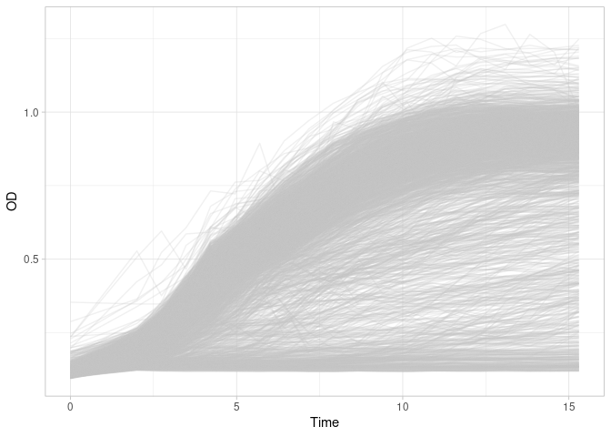

```r
plot_growth_curves(dgobj)
```

We can inspect our growth curves using variables of the metadata with the `facet` and `color` parameters.

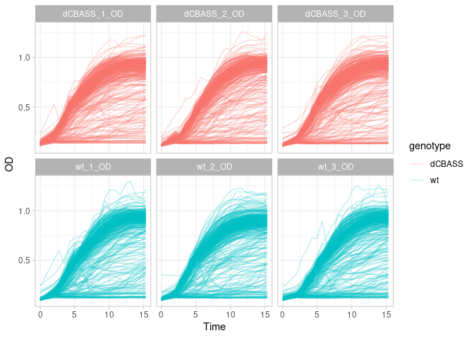

```r
plot_growth_curves(dgobj, facet="plate_name", color="genotype")
```

It’s worth mentioning that all of the plots returned by `DGrowthR` functions are [ggplot](https://ggplot2.tidyverse.org/) objects. Meaning you may further customize them to your liking using ggplot syntax and functions.

Now that our data is ready we can start pre-processing.

## Pre-processing.

Pre-processing growth curves is essential before performing any analysis. This is done by the `preprocess_data()` function. The following transformations are performed:

1. First the user may specify if some of the initial growth measurements should be ignored with the `skip_first_n_timepoints` parameter. All growth curves would be shortened so they start at timepoint skip_first_n_timepoints + 1.
2. The optical density measurements are log-transformed. This enables accurate estimation of growth parameters such as maximum specific growth rate, end of lag phase, etc. Both the log and linear scaled data are conserved.
3. Baseline correction is performed by subtracting the initial OD measurement from the rest of the growth curve.

```r
dgobj <- preprocess_data(dgobj)
```

```
#> Log-transforming the growth measurements...
#> Using OD from timepoint 1 as baseline.
```

We can see how our data has been transformed.

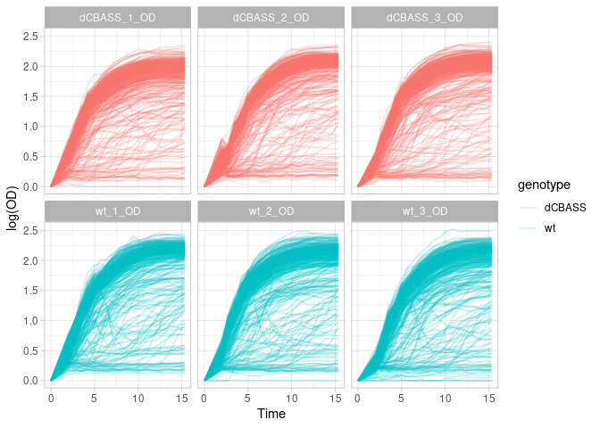

```r
plot_growth_curves(dgobj, facet="plate_name", color="genotype")
```

Notice how now the y-axis starts at 0.